# Duration Calculations

Laura F White

2023-06-07

## Methods

### Estimation of the duration of disease

We leverage countries with two prevalence surveys to determine duration and incidence of TB each year between the two prevalence surveys. To do this, we also use data on cures and deaths from TB. We assume that the ratio of prevalence to incidence is not changing over the studied time period (which implies that disease duration is also not changing). As a first, most simple approach to this problem, we determine what the ratio of prevalence to incidence must be to get us to the value of the second prevalence survey. We calculate prevalence in year $t$, $P_t$ as a function of the prior year’s prevalence, number treated, number who died and the incidence in the prior year, as follows: $P_t=P_{t-1}-C_{t-1}-D_{t-1}+I_{t-1}$, where $C_t$ and $D_t$ are the number of treated (or cured) cases of TB in year $t$ and $D_t$ are the number of deaths or self cures from TB in year $t$. We assume that the number who die or self cure have an average duration of 5 years and estimate the size of this population to be $D_t=(1/\delta_u)*(P_t-C_t)$, where $\delta_u$ is the duration of untreated disease.

We observe prevalence at two time points and have annual treatment and mortality data.

We provide more detail on the estimates of prevalence for each country below. We couple prevalance per 100,000 individuals with the population level estimates when the prevalence surveys were conducted to get the total number of prevalent TB cases, which we use in our calculation.

## Country specific Estimates

### Bangledesh

We do not have results for Bangladesh, yet. There is something odd that is producing really unusual results.

```
##      Country Year  Prevalence Treated   Incidence Duration    Prev.pop
## 1 Bangladesh 2008  114.882841     137   22.976568        5   79.000000
## 2 Bangladesh 2009    5.282841     148    1.056568        5    3.600952
## 3 Bangladesh 2010 -113.117159     142  -22.623432        5  -76.229052
## 4 Bangladesh 2011 -226.717159     142  -45.343432        5 -150.932456
## 5 Bangladesh 2012 -340.317159     155  -68.063432        5 -223.759423
## 6 Bangladesh 2013 -464.317159     172  -92.863432        5 -301.445653
## 7 Bangladesh 2014 -601.917159     178 -120.383432        5 -385.940078
## 8 Bangladesh 2015 -744.317159      NA -148.863432        5 -471.594221
##       Inc.pop Duration.u  Cure.Prev   Cure.Inc
## 1  15.8000000          5  1.1925193   5.962596
## 2   0.7201903          5 28.0152278 140.076139
## 3 -15.2458104          5 -1.2553356  -6.276678
## 4 -30.1864912          5 -0.6263311  -3.131655
## 5 -44.7518846          5 -0.4554575  -2.277287
## 6 -60.2891307          5 -0.3704365  -1.852182
## 7 -77.1880156          5 -0.2957218  -1.478609
## 8 -94.3188442          5         NA         NA
```

### Vietnam

| Country | Year | Prevalence | Treated | Incidence | Duration of treated disease | Prevalence per 100k | Incidence per 100k | Assumed duration of untreated disease | Proportion of prevalence cases treated | Proportion of incident cases treated |
| --- | --- | --- | --- | --- | --- | --- | --- | --- | --- | --- |
| Vietnam | 2007 | 374.6492 | 89.6 | 142.45218 | 2.63 | 442.0000 | 168.0608 | 5 | 0.2391570 | 0.6289830 |
| Vietnam | 2008 | 370.4916 | 89.9 | 140.87132 | 2.63 | 432.8312 | 164.5746 | 5 | 0.2426506 | 0.6381711 |
| Vietnam | 2009 | 365.3446 | 89.1 | 138.91428 | 2.63 | 422.4471 | 160.6263 | 5 | 0.2438794 | 0.6414027 |
| Vietnam | 2010 | 359.9099 | 89.6 | 136.84788 | 2.63 | 411.7444 | 156.5568 | 5 | 0.2489512 | 0.6547416 |
| Vietnam | 2011 | 353.0958 | 91.9 | 134.25697 | 2.63 | 399.6597 | 151.9619 | 5 | 0.2602693 | 0.6845082 |
| Vietnam | 2012 | 343.2136 | 92.9 | 130.49948 | 2.63 | 384.3321 | 146.1339 | 5 | 0.2706769 | 0.7118802 |
| Vietnam | 2013 | 330.7504 | 89.4 | 125.76061 | 2.63 | 366.4104 | 139.3195 | 5 | 0.2702945 | 0.7108744 |
| Vietnam | 2014 | 318.8409 | 91.3 | 121.23229 | 2.63 | 349.4702 | 132.8784 | 5 | 0.2863497 | 0.7530997 |
| Vietnam | 2015 | 303.2650 | 92.8 | 115.30989 | 2.63 | 328.9515 | 125.0766 | 5 | 0.3060030 | 0.8047878 |
| Vietnam | 2016 | 283.6819 | 93.9 | 107.86385 | 2.63 | 304.6199 | 115.8250 | 5 | 0.3310045 | 0.8705419 |
| Vietnam | 2017 | 259.6894 | NA | 98.74121 | 2.63 | 276.1682 | 105.0069 | 5 | NA | NA |

### Indonesia

| Country | Year | Prevalence | Treated | Incidence | Duration of treated disease | Prevalence per 100k | Incidence per 100k | Assumed duration of untreated disease | Proportion of prevalence cases treated | Proportion of incident cases treated |
| --- | --- | --- | --- | --- | --- | --- | --- | --- | --- | --- |
| Indonesia | 2004 | 987.3517 | 189 | 416.6041 | 2.37 | 437.0000 | 184.3882 | 5 | 0.1914212 | 0.4536681 |
| Indonesia | 2005 | 1055.2854 | 232 | 445.2681 | 2.37 | 461.2158 | 194.6058 | 5 | 0.2198457 | 0.5210344 |
| Indonesia | 2006 | 1103.8964 | 253 | 465.7791 | 2.37 | 476.2333 | 200.9423 | 5 | 0.2291882 | 0.5431760 |
| Indonesia | 2007 | 1146.4962 | 250 | 483.7537 | 2.37 | 488.1651 | 205.9768 | 5 | 0.2180557 | 0.5167919 |
| Indonesia | 2008 | 1200.9507 | 270 | 506.7302 | 2.37 | 504.7357 | 212.9686 | 5 | 0.2248219 | 0.5328279 |
| Indonesia | 2009 | 1251.4908 | 266 | 528.0552 | 2.37 | 519.3311 | 219.1270 | 5 | 0.2125465 | 0.5037352 |
| Indonesia | 2010 | 1316.4478 | 271 | 555.4632 | 2.37 | 539.4920 | 227.6338 | 5 | 0.2058570 | 0.4878811 |
| Indonesia | 2011 | 1391.8214 | 287 | 587.2664 | 2.37 | 563.2631 | 237.6638 | 5 | 0.2062046 | 0.4887049 |
| Indonesia | 2012 | 1471.1236 | 283 | 620.7272 | 2.37 | 587.9257 | 248.0699 | 5 | 0.1923700 | 0.4559168 |
| Indonesia | 2013 | 1571.2261 | 287 | 662.9646 | 2.37 | 620.3614 | 261.7559 | 5 | 0.1826599 | 0.4329040 |
| Indonesia | 2014 | 1690.3455 | NA | 713.2259 | 2.37 | 659.6991 | 278.3541 | 5 | NA | NA |

### Philippines

| Country | Year | Prevalence | Treated | Incidence | Duration of treated disease | Prevalence per 100k | Incidence per 100k | Assumed duration of untreated disease | Proportion of prevalence cases treated | Proportion of incident cases treated |
| --- | --- | --- | --- | --- | --- | --- | --- | --- | --- | --- |
| Philippines | 2007 | 972.6366 | 125 | 327.4871 | 2.97 | 1086.000 | 365.6566 | 5 | 0.1285167 | 0.3816945 |
| Philippines | 2008 | 1005.5963 | 123 | 338.5846 | 2.97 | 1101.995 | 371.0422 | 5 | 0.1223155 | 0.3632770 |
| Philippines | 2009 | 1044.6617 | 130 | 351.7379 | 2.97 | 1123.933 | 378.4287 | 5 | 0.1244422 | 0.3695934 |
| Philippines | 2010 | 1083.4673 | 151 | 364.8038 | 2.97 | 1144.870 | 385.4781 | 5 | 0.1393674 | 0.4139211 |
| Philippines | 2011 | 1110.7776 | 176 | 373.9992 | 2.97 | 1153.002 | 388.2160 | 5 | 0.1584476 | 0.4705893 |
| Philippines | 2012 | 1121.8213 | 190 | 377.7176 | 2.97 | 1144.338 | 385.2991 | 5 | 0.1693674 | 0.5030213 |
| Philippines | 2013 | 1123.1746 | 207 | 378.1733 | 2.97 | 1126.553 | 379.3108 | 5 | 0.1842990 | 0.5473681 |
| Philippines | 2014 | 1111.1129 | 224 | 374.1121 | 2.97 | 1096.581 | 369.2192 | 5 | 0.2015997 | 0.5987510 |
| Philippines | 2015 | 1083.8025 | 252 | 364.9167 | 2.97 | 1051.915 | 354.1802 | 5 | 0.2325147 | 0.6905686 |
| Philippines | 2016 | 1030.3586 | NA | 346.9221 | 2.97 | 982.461 | 330.7950 | 5 | NA | NA |

### China

| Country | Year | Prevalence | Treated | Incidence | Duration of treated disease | Prevalence per 100k | Incidence per 100k | Assumed duration of untreated disease | Proportion of prevalence cases treated | Proportion of incident cases treated |
| --- | --- | --- | --- | --- | --- | --- | --- | --- | --- | --- |
| China | 2000 | 2095.991 | 423 | 873.3295 | 2.4 | 166.0000 | 69.16667 | 5 | 0.2018139 | 0.4843533 |
| China | 2001 | 2211.722 | 447 | 921.5508 | 2.4 | 173.8980 | 72.45751 | 5 | 0.2021050 | 0.4850519 |
| China | 2002 | 2333.328 | 426 | 972.2202 | 2.4 | 182.2343 | 75.93097 | 5 | 0.1825718 | 0.4381723 |
| China | 2003 | 2498.083 | 573 | 1040.8679 | 2.4 | 193.8903 | 80.78764 | 5 | 0.2293759 | 0.5505021 |
| China | 2004 | 2580.934 | 751 | 1075.3893 | 2.4 | 199.1346 | 82.97277 | 5 | 0.2909799 | 0.6983518 |
| China | 2005 | 2539.337 | 846 | 1058.0570 | 2.4 | 194.7762 | 81.15676 | 5 | 0.3331579 | 0.7995789 |
| China | 2006 | 2412.726 | 888 | 1005.3026 | 2.4 | 184.0343 | 76.68095 | 5 | 0.3680484 | 0.8833161 |
| China | 2007 | 2225.084 | 821 | 927.1182 | 2.4 | 168.8375 | 70.34895 | 5 | 0.3689749 | 0.8855397 |
| China | 2008 | 2050.385 | 917 | 854.3271 | 2.4 | 154.7863 | 64.49431 | 5 | 0.4472331 | 1.0733593 |
| China | 2009 | 1761.035 | 917 | 733.7647 | 2.4 | 132.2833 | 55.11806 | 5 | 0.5207164 | 1.2497195 |
| China | 2010 | 1408.993 | NA | 587.0804 | 2.4 | 105.3291 | 43.88713 | 5 | NA | NA |

### Cambodia

| Country | Year | Prevalence | Treated | Incidence | Duration of treated disease | Prevalence per 100k | Incidence per 100k | Assumed duration of untreated disease | Proportion of prevalence cases treated | Proportion of incident cases treated |
| --- | --- | --- | --- | --- | --- | --- | --- | --- | --- | --- |
| Cambodia | 2002 | 187.2961 | 23 | 57.10248 | 3.28 | 1491.0000 | 454.5732 | 5 | 0.1228002 | 0.4027846 |
| Cambodia | 2003 | 188.5394 | 26 | 57.48152 | 3.28 | 1474.3795 | 449.5060 | 5 | 0.1379022 | 0.4523193 |
| Cambodia | 2004 | 187.5130 | 28 | 57.16860 | 3.28 | 1440.5937 | 439.2054 | 5 | 0.1493230 | 0.4897793 |
| Cambodia | 2005 | 184.7790 | 33 | 56.33507 | 3.28 | 1394.9184 | 425.2800 | 5 | 0.1785917 | 0.5857808 |
| Cambodia | 2006 | 177.7583 | 32 | 54.19460 | 3.28 | 1318.8989 | 402.1033 | 5 | 0.1800197 | 0.5904648 |
| Cambodia | 2007 | 170.8012 | 33 | 52.07354 | 3.28 | 1245.3797 | 379.6889 | 5 | 0.1932070 | 0.6337191 |
| Cambodia | 2008 | 162.3145 | 37 | 49.48613 | 3.28 | 1164.0550 | 354.8948 | 5 | 0.2279525 | 0.7476842 |
| Cambodia | 2009 | 149.7378 | 37 | 45.65175 | 3.28 | 1057.7882 | 322.4964 | 5 | 0.2470987 | 0.8104836 |
| Cambodia | 2010 | 135.8420 | 38 | 41.41523 | 3.28 | 945.7420 | 288.3360 | 5 | 0.2797368 | 0.9175368 |
| Cambodia | 2011 | 119.6888 | NA | 36.49049 | 3.28 | 821.2552 | 250.3827 | 5 | NA | NA |

### Myanmar

| Country | Year | Prevalence | Treated | Incidence | Duration of treated disease | Prevalence per 100k | Incidence per 100k | Assumed duration of untreated disease | Proportion of prevalence cases treated | Proportion of incident cases treated |
| --- | --- | --- | --- | --- | --- | --- | --- | --- | --- | --- |
| Myanmar | 2009 | 415.1641 | 109 | 166.73258 | 2.49 | 847.0000 | 340.1606 | 5 | 0.2625468 | 0.6537414 |
| Myanmar | 2010 | 411.6639 | 113 | 165.32686 | 2.49 | 833.4798 | 334.7308 | 5 | 0.2744958 | 0.6834945 |
| Myanmar | 2011 | 404.2580 | 118 | 162.35260 | 2.49 | 811.8523 | 326.0451 | 5 | 0.2918928 | 0.7268131 |
| Myanmar | 2012 | 391.3590 | 126 | 157.17228 | 2.49 | 779.3172 | 312.9788 | 5 | 0.3219551 | 0.8016681 |
| Myanmar | 2013 | 369.4595 | 117 | 148.37729 | 2.49 | 729.4602 | 292.9559 | 5 | 0.3166789 | 0.7885304 |
| Myanmar | 2014 | 350.3449 | 120 | 140.70075 | 2.49 | 685.9764 | 275.4925 | 5 | 0.3425197 | 0.8528739 |
| Myanmar | 2015 | 324.9766 | 120 | 130.51271 | 2.49 | 631.2193 | 253.5017 | 5 | 0.3692573 | 0.9194507 |
| Myanmar | 2016 | 294.4940 | 121 | 118.27069 | 2.49 | 567.5095 | 227.9155 | 5 | 0.4108742 | 1.0230768 |
| Myanmar | 2017 | 257.0659 | 113 | 103.23932 | 2.49 | 491.6314 | 197.4423 | 5 | 0.4395760 | 1.0945442 |
| Myanmar | 2018 | 218.4920 | NA | 87.74781 | 2.49 | 414.8634 | 166.6118 | 5 | NA | NA |

## Plotting the relationship between Duration and other parameters

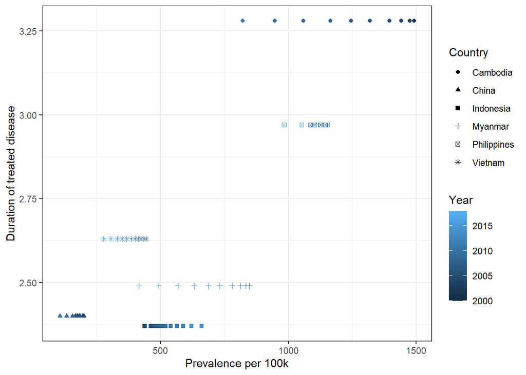

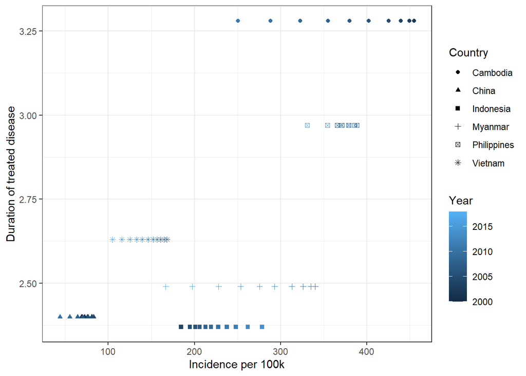

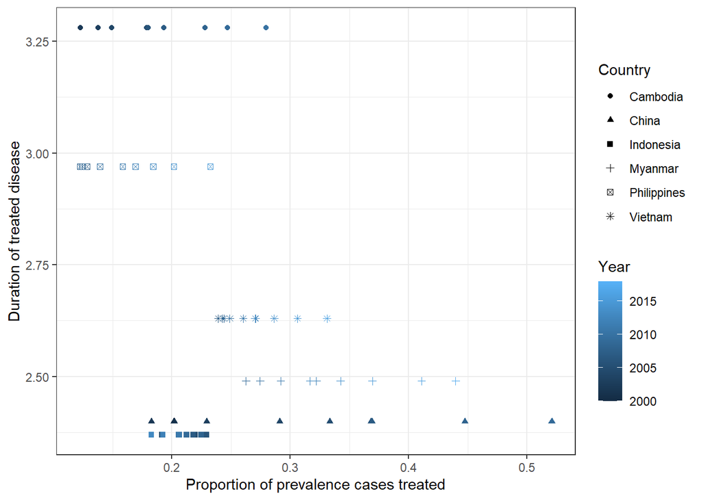

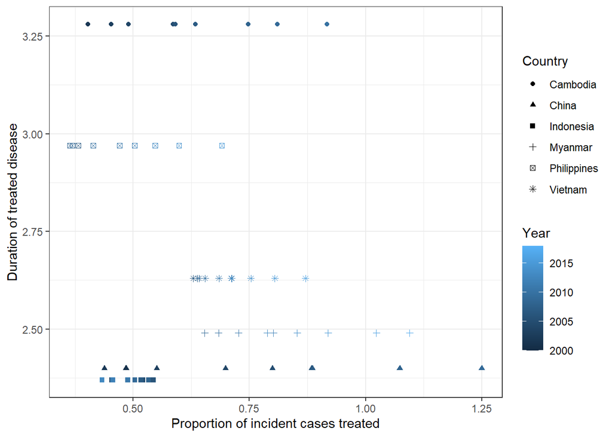

## Sensitivity analysis for duration of untreated disease

We previously assumed that the duration of untreated disease is five years. We now vary this to be 4 years and 6 years to determine how much it alters the results.

### Vietnam

| Country | Year | Prevalence | Treated | Incidence | Duration of treated disease | Prevalence per 100k | Incidence per 100k | Assumed duration of untreated disease | Proportion of prevalence cases treated | Proportion of incident cases treated |
| --- | --- | --- | --- | --- | --- | --- | --- | --- | --- | --- |
| Vietnam | 2007 | 374.6492 | 89.6 | 156.75700 | 2.39 | 442.0000 | 184.93724 | 4 | 0.2391570 | 0.5715853 |
| Vietnam | 2008 | 370.5439 | 89.9 | 155.03930 | 2.39 | 432.8924 | 181.12651 | 4 | 0.2426163 | 0.5798530 |
| Vietnam | 2009 | 365.5222 | 89.1 | 152.93818 | 2.39 | 422.6525 | 176.84205 | 4 | 0.2437608 | 0.5825884 |
| Vietnam | 2010 | 360.2549 | 89.6 | 150.73425 | 2.39 | 412.1390 | 172.44309 | 4 | 0.2487128 | 0.5944236 |
| Vietnam | 2011 | 353.7254 | 91.9 | 148.00225 | 2.39 | 400.3723 | 167.51979 | 4 | 0.2598061 | 0.6209365 |
| Vietnam | 2012 | 344.3713 | 92.9 | 144.08841 | 2.39 | 385.6284 | 161.35081 | 4 | 0.2697670 | 0.6447430 |
| Vietnam | 2013 | 332.6919 | 89.4 | 139.20162 | 2.39 | 368.5612 | 154.20972 | 4 | 0.2687171 | 0.6422339 |
| Vietnam | 2014 | 321.6705 | 91.3 | 134.59018 | 2.39 | 352.5717 | 147.51952 | 4 | 0.2838308 | 0.6783556 |
| Vietnam | 2015 | 307.3681 | 92.8 | 128.60589 | 2.39 | 333.4021 | 139.49880 | 4 | 0.3019181 | 0.7215844 |
| Vietnam | 2016 | 289.5320 | 93.9 | 121.14308 | 2.39 | 310.9017 | 130.08439 | 4 | 0.3243165 | 0.7751165 |
| Vietnam | 2017 | 267.8670 | NA | 112.07826 | 2.39 | 284.8648 | 119.19029 | 4 | NA | NA |
| Vietnam | 2007 | 374.6492 | 89.6 | 142.45218 | 2.63 | 442.0000 | 168.06084 | 5 | 0.2391570 | 0.6289830 |
| Vietnam | 2008 | 370.4916 | 89.9 | 140.87132 | 2.63 | 432.8312 | 164.57460 | 5 | 0.2426506 | 0.6381711 |
| Vietnam | 2009 | 365.3446 | 89.1 | 138.91428 | 2.63 | 422.4471 | 160.62626 | 5 | 0.2438794 | 0.6414027 |
| Vietnam | 2010 | 359.9099 | 89.6 | 136.84788 | 2.63 | 411.7444 | 156.55680 | 5 | 0.2489512 | 0.6547416 |
| Vietnam | 2011 | 353.0958 | 91.9 | 134.25697 | 2.63 | 399.6597 | 151.96187 | 5 | 0.2602693 | 0.6845082 |
| Vietnam | 2012 | 343.2136 | 92.9 | 130.49948 | 2.63 | 384.3321 | 146.13387 | 5 | 0.2706769 | 0.7118802 |
| Vietnam | 2013 | 330.7504 | 89.4 | 125.76061 | 2.63 | 366.4104 | 139.31955 | 5 | 0.2702945 | 0.7108744 |
| Vietnam | 2014 | 318.8409 | 91.3 | 121.23229 | 2.63 | 349.4702 | 132.87841 | 5 | 0.2863497 | 0.7530997 |
| Vietnam | 2015 | 303.2650 | 92.8 | 115.30989 | 2.63 | 328.9515 | 125.07663 | 5 | 0.3060030 | 0.8047878 |
| Vietnam | 2016 | 283.6819 | 93.9 | 107.86385 | 2.63 | 304.6199 | 115.82505 | 5 | 0.3310045 | 0.8705419 |
| Vietnam | 2017 | 259.6894 | NA | 98.74121 | 2.63 | 276.1682 | 105.00692 | 5 | NA | NA |
| Vietnam | 2007 | 374.6492 | 89.6 | 133.32713 | 2.81 | 442.0000 | 157.29537 | 6 | 0.2391570 | 0.6720313 |
| Vietnam | 2008 | 370.8682 | 89.9 | 131.98155 | 2.81 | 433.2712 | 154.18902 | 6 | 0.2424042 | 0.6811558 |
| Vietnam | 2009 | 366.1217 | 89.1 | 130.29241 | 2.81 | 423.3456 | 150.65681 | 6 | 0.2433617 | 0.6838464 |
| Vietnam | 2010 | 361.1438 | 89.6 | 128.52093 | 2.81 | 413.1560 | 147.03059 | 6 | 0.2481006 | 0.6971627 |
| Vietnam | 2011 | 354.8074 | 91.9 | 126.26599 | 2.81 | 401.5970 | 142.91709 | 6 | 0.2590137 | 0.7278286 |
| Vietnam | 2012 | 345.3555 | 92.9 | 122.90232 | 2.81 | 386.7306 | 137.62653 | 6 | 0.2689982 | 0.7558848 |
| Vietnam | 2013 | 333.2819 | 89.4 | 118.60567 | 2.81 | 369.2149 | 131.39319 | 6 | 0.2682414 | 0.7537583 |
| Vietnam | 2014 | 321.8406 | 91.3 | 114.53402 | 2.81 | 352.7581 | 125.53668 | 6 | 0.2836808 | 0.7971431 |
| Vietnam | 2015 | 306.6512 | 92.8 | 109.12854 | 2.81 | 332.6245 | 118.37171 | 6 | 0.3026240 | 0.8503734 |
| Vietnam | 2016 | 287.3379 | 93.9 | 102.25547 | 2.81 | 308.5457 | 109.80272 | 6 | 0.3267930 | 0.9182883 |
| Vietnam | 2017 | 263.4537 | NA | 93.75576 | 2.81 | 280.1714 | 99.70511 | 6 | NA | NA |

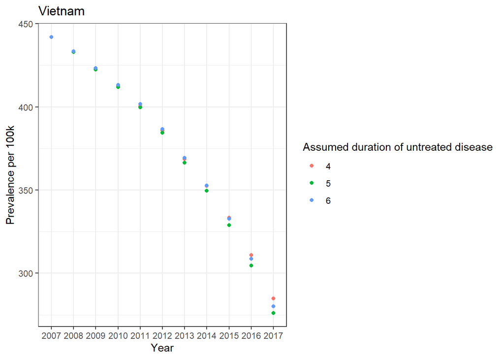

### Indonesia

| Country | Year | Prevalence | Treated | Incidence | Duration of treated disease | Prevalence per 100k | Incidence per 100k | Assumed duration of untreated disease | Proportion of prevalence cases treated | Proportion of incident cases treated |
| --- | --- | --- | --- | --- | --- | --- | --- | --- | --- | --- |
| Indonesia | 2004 | 987.3517 | 189 | 455.0008 | 2.17 | 437.0000 | 201.3825 | 4 | 0.1914212 | 0.4153839 |
| Indonesia | 2005 | 1053.7645 | 232 | 485.6058 | 2.17 | 460.5511 | 212.2355 | 4 | 0.2201630 | 0.4777538 |
| Indonesia | 2006 | 1101.9291 | 253 | 507.8015 | 2.17 | 475.3845 | 219.0712 | 4 | 0.2295973 | 0.4982262 |
| Indonesia | 2007 | 1144.4983 | 250 | 527.4186 | 2.17 | 487.3144 | 224.5689 | 4 | 0.2184363 | 0.4740068 |
| Indonesia | 2008 | 1198.2923 | 270 | 552.2084 | 2.17 | 503.6184 | 232.0822 | 4 | 0.2253206 | 0.4889458 |
| Indonesia | 2009 | 1248.4277 | 266 | 575.3123 | 2.17 | 518.0600 | 238.7373 | 4 | 0.2130680 | 0.4623576 |
| Indonesia | 2010 | 1312.1330 | 271 | 604.6696 | 2.17 | 537.7238 | 247.7990 | 4 | 0.2065339 | 0.4481786 |
| Indonesia | 2011 | 1385.5194 | 287 | 638.4882 | 2.17 | 560.7127 | 258.3930 | 4 | 0.2071425 | 0.4494993 |
| Indonesia | 2012 | 1462.3777 | 283 | 673.9068 | 2.17 | 584.4305 | 269.3228 | 4 | 0.1935205 | 0.4199394 |
| Indonesia | 2013 | 1558.4401 | 287 | 718.1752 | 2.17 | 615.3132 | 283.5545 | 4 | 0.1841585 | 0.3996240 |
| Indonesia | 2014 | 1671.7552 | NA | 770.3941 | 2.17 | 652.4438 | 300.6654 | 4 | NA | NA |
| Indonesia | 2004 | 987.3517 | 189 | 416.6041 | 2.37 | 437.0000 | 184.3882 | 5 | 0.1914212 | 0.4536681 |
| Indonesia | 2005 | 1055.2854 | 232 | 445.2681 | 2.37 | 461.2158 | 194.6058 | 5 | 0.2198457 | 0.5210344 |
| Indonesia | 2006 | 1103.8964 | 253 | 465.7791 | 2.37 | 476.2333 | 200.9423 | 5 | 0.2291882 | 0.5431760 |
| Indonesia | 2007 | 1146.4962 | 250 | 483.7537 | 2.37 | 488.1651 | 205.9768 | 5 | 0.2180557 | 0.5167919 |
| Indonesia | 2008 | 1200.9507 | 270 | 506.7302 | 2.37 | 504.7357 | 212.9686 | 5 | 0.2248219 | 0.5328279 |
| Indonesia | 2009 | 1251.4908 | 266 | 528.0552 | 2.37 | 519.3311 | 219.1270 | 5 | 0.2125465 | 0.5037352 |
| Indonesia | 2010 | 1316.4478 | 271 | 555.4632 | 2.37 | 539.4920 | 227.6338 | 5 | 0.2058570 | 0.4878811 |
| Indonesia | 2011 | 1391.8214 | 287 | 587.2664 | 2.37 | 563.2631 | 237.6638 | 5 | 0.2062046 | 0.4887049 |
| Indonesia | 2012 | 1471.1236 | 283 | 620.7272 | 2.37 | 587.9257 | 248.0699 | 5 | 0.1923700 | 0.4559168 |
| Indonesia | 2013 | 1571.2261 | 287 | 662.9646 | 2.37 | 620.3614 | 261.7559 | 5 | 0.1826599 | 0.4329040 |
| Indonesia | 2014 | 1690.3455 | NA | 713.2259 | 2.37 | 659.6991 | 278.3541 | 5 | NA | NA |
| Indonesia | 2004 | 987.3517 | 189 | 390.2576 | 2.53 | 437.0000 | 172.7273 | 6 | 0.1914212 | 0.4842955 |
| Indonesia | 2005 | 1055.5506 | 232 | 417.2137 | 2.53 | 461.3317 | 182.3445 | 6 | 0.2197905 | 0.5560700 |
| Indonesia | 2006 | 1103.5059 | 253 | 436.1683 | 2.53 | 476.0648 | 188.1679 | 6 | 0.2292693 | 0.5800513 |
| Indonesia | 2007 | 1144.9232 | 250 | 452.5388 | 2.53 | 487.4953 | 192.6859 | 6 | 0.2183553 | 0.5524388 |
| Indonesia | 2008 | 1198.3082 | 270 | 473.6396 | 2.53 | 503.6251 | 199.0613 | 6 | 0.2253177 | 0.5700537 |
| Indonesia | 2009 | 1247.2297 | 266 | 492.9762 | 2.53 | 517.5629 | 204.5703 | 6 | 0.2132727 | 0.5395798 |
| Indonesia | 2010 | 1310.6676 | 271 | 518.0504 | 2.53 | 537.1233 | 212.3017 | 6 | 0.2067649 | 0.5231151 |
| Indonesia | 2011 | 1384.4401 | 287 | 547.2095 | 2.53 | 560.2759 | 221.4529 | 6 | 0.2073040 | 0.5244792 |
| Indonesia | 2012 | 1461.7430 | 283 | 577.7640 | 2.53 | 584.1768 | 230.8999 | 6 | 0.1936045 | 0.4898193 |
| Indonesia | 2013 | 1560.0499 | 287 | 616.6205 | 2.53 | 615.9488 | 243.4580 | 6 | 0.1839685 | 0.4654403 |
| Indonesia | 2014 | 1677.4954 | NA | 663.0416 | 2.53 | 654.6840 | 258.7684 | 6 | NA | NA |

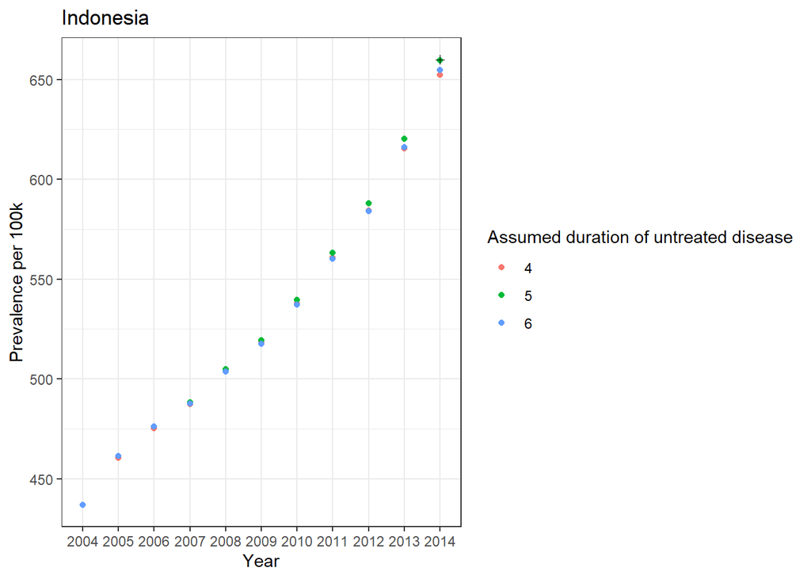

### Philippines

| Country | Year | Prevalence | Treated | Incidence | Duration of treated disease | Prevalence per 100k | Incidence per 100k | Assumed duration of untreated disease | Proportion of prevalence cases treated | Proportion of incident cases treated |
| --- | --- | --- | --- | --- | --- | --- | --- | --- | --- | --- |
| Philippines | 2007 | 972.6366 | 125 | 368.4229 | 2.64 | 1086.0000 | 411.3636 | 4 | 0.1285167 | 0.3392840 |
| Philippines | 2008 | 1004.1504 | 123 | 380.3600 | 2.64 | 1100.4107 | 416.8222 | 4 | 0.1224916 | 0.3233779 |
| Philippines | 2009 | 1041.2227 | 130 | 394.4026 | 2.64 | 1120.2334 | 424.3308 | 4 | 0.1248532 | 0.3296125 |
| Philippines | 2010 | 1077.8196 | 151 | 408.2650 | 2.64 | 1138.9024 | 431.4024 | 4 | 0.1400977 | 0.3698578 |
| Philippines | 2011 | 1103.3797 | 176 | 417.9469 | 2.64 | 1145.3224 | 433.8343 | 4 | 0.1595099 | 0.4211062 |
| Philippines | 2012 | 1113.4817 | 190 | 421.7734 | 2.64 | 1135.8312 | 430.2391 | 4 | 0.1706360 | 0.4504789 |
| Philippines | 2013 | 1114.3846 | 207 | 422.1154 | 2.64 | 1117.7366 | 423.3851 | 4 | 0.1857527 | 0.4903873 |
| Philippines | 2014 | 1102.6538 | 224 | 417.6719 | 2.64 | 1088.2325 | 412.2093 | 4 | 0.2031463 | 0.5363061 |
| Philippines | 2015 | 1076.6623 | 252 | 407.8266 | 2.64 | 1044.9850 | 395.8276 | 4 | 0.2340567 | 0.6179096 |
| Philippines | 2016 | 1026.3233 | NA | 388.7588 | 2.64 | 978.6133 | 370.6869 | 4 | NA | NA |
| Philippines | 2007 | 972.6366 | 125 | 327.4871 | 2.97 | 1086.0000 | 365.6566 | 5 | 0.1285167 | 0.3816945 |
| Philippines | 2008 | 1005.5963 | 123 | 338.5846 | 2.97 | 1101.9953 | 371.0422 | 5 | 0.1223155 | 0.3632770 |
| Philippines | 2009 | 1044.6617 | 130 | 351.7379 | 2.97 | 1123.9332 | 378.4287 | 5 | 0.1244422 | 0.3695934 |
| Philippines | 2010 | 1083.4673 | 151 | 364.8038 | 2.97 | 1144.8701 | 385.4781 | 5 | 0.1393674 | 0.4139211 |
| Philippines | 2011 | 1110.7776 | 176 | 373.9992 | 2.97 | 1153.0015 | 388.2160 | 5 | 0.1584476 | 0.4705893 |
| Philippines | 2012 | 1121.8213 | 190 | 377.7176 | 2.97 | 1144.3382 | 385.2991 | 5 | 0.1693674 | 0.5030213 |
| Philippines | 2013 | 1123.1746 | 207 | 378.1733 | 2.97 | 1126.5531 | 379.3108 | 5 | 0.1842990 | 0.5473681 |
| Philippines | 2014 | 1111.1129 | 224 | 374.1121 | 2.97 | 1096.5810 | 369.2192 | 5 | 0.2015997 | 0.5987510 |
| Philippines | 2015 | 1083.8025 | 252 | 364.9167 | 2.97 | 1051.9151 | 354.1802 | 5 | 0.2325147 | 0.6905686 |
| Philippines | 2016 | 1030.3586 | NA | 346.9221 | 2.97 | 982.4610 | 330.7950 | 5 | NA | NA |
| Philippines | 2007 | 972.6366 | 125 | 300.1965 | 3.24 | 1086.0000 | 335.1852 | 6 | 0.1285167 | 0.4163940 |
| Philippines | 2008 | 1006.5603 | 123 | 310.6667 | 3.24 | 1103.0516 | 340.4480 | 6 | 0.1221983 | 0.3959226 |
| Philippines | 2009 | 1046.9670 | 130 | 323.1380 | 3.24 | 1126.4135 | 347.6585 | 6 | 0.1241682 | 0.4023050 |
| Philippines | 2010 | 1087.2771 | 151 | 335.5793 | 3.24 | 1148.8958 | 354.5975 | 6 | 0.1388790 | 0.4499681 |
| Philippines | 2011 | 1115.8103 | 176 | 344.3859 | 3.24 | 1158.2255 | 357.4770 | 6 | 0.1577329 | 0.5110546 |
| Philippines | 2012 | 1127.5611 | 190 | 348.0127 | 3.24 | 1150.1933 | 354.9979 | 6 | 0.1685053 | 0.5459571 |
| Philippines | 2013 | 1129.3136 | 207 | 348.5536 | 3.24 | 1132.7105 | 349.6020 | 6 | 0.1832972 | 0.5938829 |
| Philippines | 2014 | 1117.1482 | 224 | 344.7988 | 3.24 | 1102.5374 | 340.2893 | 6 | 0.2005105 | 0.6496542 |
| Philippines | 2015 | 1089.0890 | 252 | 336.1386 | 3.24 | 1057.0461 | 326.2488 | 6 | 0.2313860 | 0.7496908 |
| Philippines | 2016 | 1033.7128 | NA | 319.0472 | 3.24 | 985.6593 | 304.2158 | 6 | NA | NA |

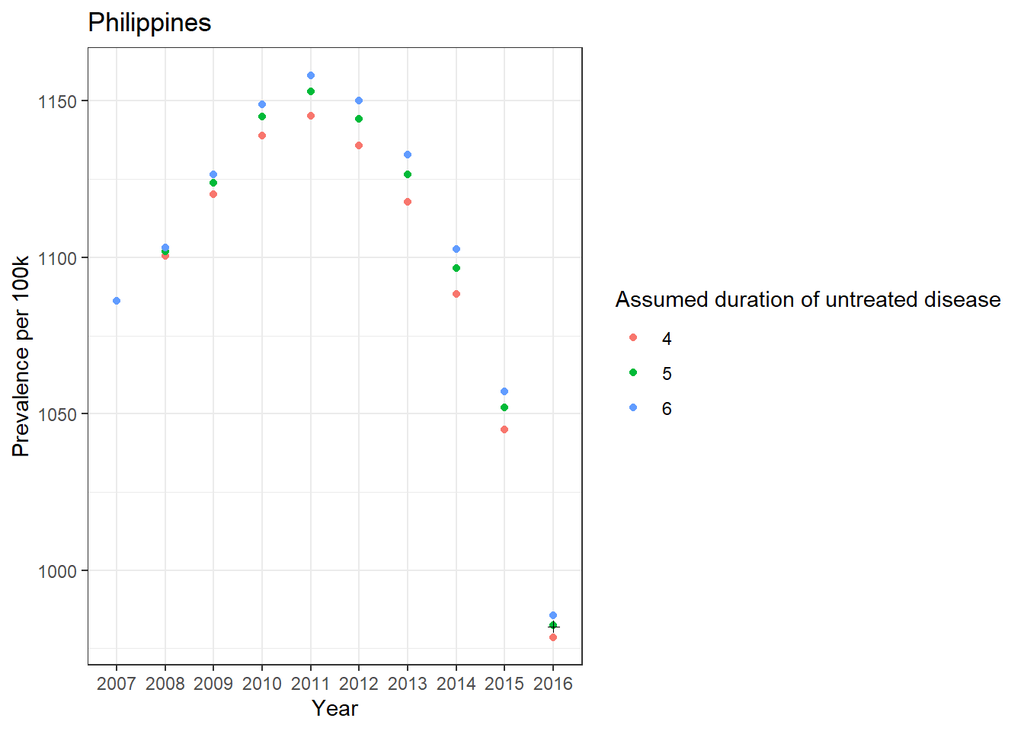

### China

| Country | Year | Prevalence | Treated | Incidence | Duration of treated disease | Prevalence per 100k | Incidence per 100k | Assumed duration of untreated disease | Proportion of prevalence cases treated | Proportion of incident cases treated |
| --- | --- | --- | --- | --- | --- | --- | --- | --- | --- | --- |
| China | 2000 | 2095.991 | 423 | 952.7230 | 2.20 | 166.0000 | 75.45455 | 4 | 0.2018139 | 0.4439905 |
| China | 2001 | 2207.466 | 447 | 1003.3937 | 2.20 | 173.5634 | 78.89245 | 4 | 0.2024946 | 0.4454882 |
| China | 2002 | 2323.743 | 426 | 1056.2469 | 2.20 | 181.4857 | 82.49351 | 4 | 0.1833249 | 0.4033148 |
| China | 2003 | 2479.554 | 573 | 1127.0702 | 2.20 | 192.4522 | 87.47828 | 4 | 0.2310899 | 0.5083978 |
| China | 2004 | 2556.986 | 751 | 1162.2663 | 2.20 | 197.2869 | 89.67585 | 4 | 0.2937052 | 0.6461514 |
| China | 2005 | 2516.756 | 846 | 1143.9799 | 2.20 | 193.0442 | 87.74736 | 4 | 0.3361470 | 0.7395235 |
| China | 2006 | 2397.047 | 888 | 1089.5667 | 2.20 | 182.8383 | 83.10832 | 4 | 0.3704559 | 0.8150029 |
| China | 2007 | 2221.352 | 821 | 1009.7053 | 2.20 | 168.5543 | 76.61559 | 4 | 0.3695948 | 0.8131085 |
| China | 2008 | 2059.969 | 917 | 936.3496 | 2.20 | 155.5099 | 70.68630 | 4 | 0.4451523 | 0.9793351 |
| China | 2009 | 1793.576 | 917 | 815.2620 | 2.20 | 134.7277 | 61.23988 | 4 | 0.5112690 | 1.1247918 |
| China | 2010 | 1472.694 | NA | 669.4065 | 2.20 | 110.0911 | 50.04141 | 4 | NA | NA |
| China | 2000 | 2095.991 | 423 | 873.3295 | 2.40 | 166.0000 | 69.16667 | 5 | 0.2018139 | 0.4843533 |
| China | 2001 | 2211.722 | 447 | 921.5508 | 2.40 | 173.8980 | 72.45751 | 5 | 0.2021050 | 0.4850519 |
| China | 2002 | 2333.328 | 426 | 972.2202 | 2.40 | 182.2343 | 75.93097 | 5 | 0.1825718 | 0.4381723 |
| China | 2003 | 2498.083 | 573 | 1040.8679 | 2.40 | 193.8903 | 80.78764 | 5 | 0.2293759 | 0.5505021 |
| China | 2004 | 2580.934 | 751 | 1075.3893 | 2.40 | 199.1346 | 82.97277 | 5 | 0.2909799 | 0.6983518 |
| China | 2005 | 2539.337 | 846 | 1058.0570 | 2.40 | 194.7762 | 81.15676 | 5 | 0.3331579 | 0.7995789 |
| China | 2006 | 2412.726 | 888 | 1005.3026 | 2.40 | 184.0343 | 76.68095 | 5 | 0.3680484 | 0.8833161 |
| China | 2007 | 2225.084 | 821 | 927.1182 | 2.40 | 168.8375 | 70.34895 | 5 | 0.3689749 | 0.8855397 |
| China | 2008 | 2050.385 | 917 | 854.3271 | 2.40 | 154.7863 | 64.49431 | 5 | 0.4472331 | 1.0733593 |
| China | 2009 | 1761.035 | 917 | 733.7647 | 2.40 | 132.2833 | 55.11806 | 5 | 0.5207164 | 1.2497195 |
| China | 2010 | 1408.993 | NA | 587.0804 | 2.40 | 105.3291 | 43.88713 | 5 | NA | NA |
| China | 2000 | 2095.991 | 423 | 821.9571 | 2.55 | 166.0000 | 65.09804 | 6 | 0.2018139 | 0.5146254 |
| China | 2001 | 2216.116 | 447 | 869.0651 | 2.55 | 174.2435 | 68.33079 | 6 | 0.2017042 | 0.5143458 |
| China | 2002 | 2343.328 | 426 | 918.9524 | 2.55 | 183.0153 | 71.77072 | 6 | 0.1817927 | 0.4635714 |
| China | 2003 | 2516.726 | 573 | 986.9514 | 2.55 | 195.3373 | 76.60287 | 6 | 0.2276767 | 0.5805757 |
| China | 2004 | 2606.723 | 751 | 1022.2444 | 2.55 | 201.1244 | 78.87232 | 6 | 0.2881012 | 0.7346580 |
| China | 2005 | 2568.680 | 846 | 1007.3256 | 2.55 | 197.0270 | 77.26549 | 6 | 0.3293520 | 0.8398476 |
| China | 2006 | 2442.893 | 888 | 957.9971 | 2.55 | 186.3353 | 73.07265 | 6 | 0.3635035 | 0.9269339 |
| China | 2007 | 2253.741 | 821 | 883.8200 | 2.55 | 171.0120 | 67.06351 | 6 | 0.3642832 | 0.9289222 |
| China | 2008 | 2077.771 | 917 | 814.8120 | 2.55 | 156.8537 | 61.51126 | 6 | 0.4413384 | 1.1254129 |
| China | 2009 | 1782.121 | 917 | 698.8710 | 2.55 | 133.8672 | 52.49696 | 6 | 0.5145554 | 1.3121163 |
| China | 2010 | 1419.805 | NA | 556.7863 | 2.55 | 106.1374 | 41.62250 | 6 | NA | NA |

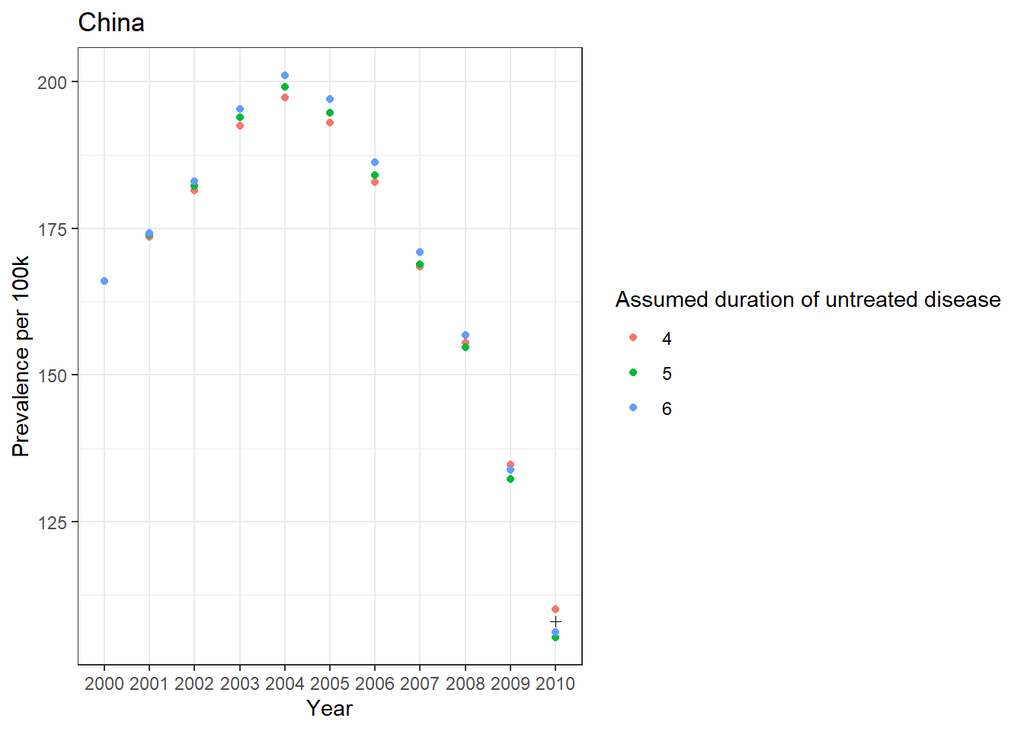

### Cambodia

| Country | Year | Prevalence | Treated | Incidence | Duration of treated disease | Prevalence per 100k | Incidence per 100k | Assumed duration of untreated disease | Proportion of prevalence cases treated | Proportion of incident cases treated |
| --- | --- | --- | --- | --- | --- | --- | --- | --- | --- | --- |
| Cambodia | 2002 | 187.2961 | 23 | 64.80835 | 2.89 | 1491.0000 | 515.9170 | 4 | 0.1228002 | 0.3548926 |
| Cambodia | 2003 | 188.0304 | 26 | 65.06244 | 2.89 | 1470.3996 | 508.7888 | 4 | 0.1382755 | 0.3996161 |
| Cambodia | 2004 | 186.5853 | 28 | 64.56238 | 2.89 | 1433.4661 | 496.0090 | 4 | 0.1500654 | 0.4336891 |
| Cambodia | 2005 | 183.5013 | 33 | 63.49527 | 2.89 | 1385.2729 | 479.3332 | 4 | 0.1798352 | 0.5197238 |
| Cambodia | 2006 | 176.3713 | 32 | 61.02812 | 2.89 | 1308.6078 | 452.8055 | 4 | 0.1814355 | 0.5243485 |
| Cambodia | 2007 | 169.3066 | 33 | 58.58359 | 2.89 | 1234.4816 | 427.1563 | 4 | 0.1949127 | 0.5632977 |
| Cambodia | 2008 | 160.8135 | 37 | 55.64481 | 2.89 | 1153.2903 | 399.0624 | 4 | 0.2300802 | 0.6649317 |
| Cambodia | 2009 | 148.5049 | 37 | 51.38580 | 2.89 | 1049.0794 | 363.0032 | 4 | 0.2491499 | 0.7200433 |
| Cambodia | 2010 | 135.0145 | 38 | 46.71782 | 2.89 | 939.9812 | 325.2530 | 4 | 0.2814512 | 0.8133941 |
| Cambodia | 2011 | 119.4787 | NA | 41.34211 | 2.89 | 819.8137 | 283.6726 | 4 | NA | NA |
| Cambodia | 2002 | 187.2961 | 23 | 57.10248 | 3.28 | 1491.0000 | 454.5732 | 5 | 0.1228002 | 0.4027846 |
| Cambodia | 2003 | 188.5394 | 26 | 57.48152 | 3.28 | 1474.3795 | 449.5060 | 5 | 0.1379022 | 0.4523193 |
| Cambodia | 2004 | 187.5130 | 28 | 57.16860 | 3.28 | 1440.5937 | 439.2054 | 5 | 0.1493230 | 0.4897793 |
| Cambodia | 2005 | 184.7790 | 33 | 56.33507 | 3.28 | 1394.9184 | 425.2800 | 5 | 0.1785917 | 0.5857808 |
| Cambodia | 2006 | 177.7583 | 32 | 54.19460 | 3.28 | 1318.8989 | 402.1033 | 5 | 0.1800197 | 0.5904648 |
| Cambodia | 2007 | 170.8012 | 33 | 52.07354 | 3.28 | 1245.3797 | 379.6889 | 5 | 0.1932070 | 0.6337191 |
| Cambodia | 2008 | 162.3145 | 37 | 49.48613 | 3.28 | 1164.0550 | 354.8948 | 5 | 0.2279525 | 0.7476842 |
| Cambodia | 2009 | 149.7378 | 37 | 45.65175 | 3.28 | 1057.7882 | 322.4964 | 5 | 0.2470987 | 0.8104836 |
| Cambodia | 2010 | 135.8420 | 38 | 41.41523 | 3.28 | 945.7420 | 288.3360 | 5 | 0.2797368 | 0.9175368 |
| Cambodia | 2011 | 119.6888 | NA | 36.49049 | 3.28 | 821.2552 | 250.3827 | 5 | NA | NA |
| Cambodia | 2002 | 187.2961 | 23 | 51.88258 | 3.61 | 1491.0000 | 413.0194 | 6 | 0.1228002 | 0.4433087 |
| Cambodia | 2003 | 188.7960 | 26 | 52.29807 | 3.61 | 1476.3865 | 408.9713 | 6 | 0.1377148 | 0.4971503 |
| Cambodia | 2004 | 187.9614 | 28 | 52.06687 | 3.61 | 1444.0386 | 400.0107 | 6 | 0.1489667 | 0.5377699 |
| Cambodia | 2005 | 185.3681 | 33 | 51.34849 | 3.61 | 1399.3651 | 387.6358 | 6 | 0.1780242 | 0.6426674 |
| Cambodia | 2006 | 178.3219 | 32 | 49.39664 | 3.61 | 1323.0805 | 366.5043 | 6 | 0.1794508 | 0.6478173 |
| Cambodia | 2007 | 171.3315 | 33 | 47.46026 | 3.61 | 1249.2464 | 346.0516 | 6 | 0.1926090 | 0.6953186 |
| Cambodia | 2008 | 162.7365 | 37 | 45.07937 | 3.61 | 1167.0815 | 323.2913 | 6 | 0.2273614 | 0.8207745 |
| Cambodia | 2009 | 149.8598 | 37 | 41.51242 | 3.61 | 1058.6506 | 293.2550 | 6 | 0.2468974 | 0.8912996 |
| Cambodia | 2010 | 135.5623 | 38 | 37.55187 | 3.61 | 943.7948 | 261.4390 | 6 | 0.2803140 | 1.0119335 |
| Cambodia | 2011 | 118.8538 | NA | 32.92348 | 3.61 | 815.5256 | 225.9074 | 6 | NA | NA |

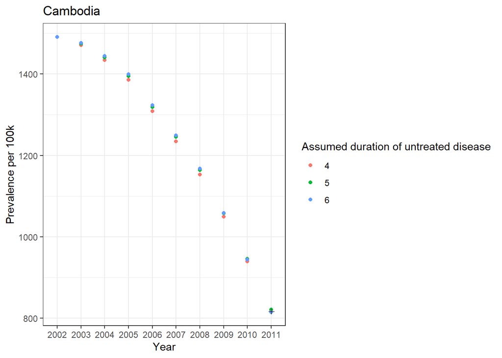

### Myanmar

| Country | Year | Prevalence | Treated | Incidence | Duration of treated disease | Prevalence per 100k | Incidence per 100k | Assumed duration of untreated disease | Proportion of prevalence cases treated | Proportion of incident cases treated |
| --- | --- | --- | --- | --- | --- | --- | --- | --- | --- | --- |
| Myanmar | 2009 | 415.1641 | 109 | 181.29438 | 2.29 | 847.0000 | 369.8690 | 4 | 0.2625468 | 0.6012321 |
| Myanmar | 2010 | 410.9175 | 113 | 179.43995 | 2.29 | 831.9685 | 363.3050 | 4 | 0.2749944 | 0.6297371 |
| Myanmar | 2011 | 402.8781 | 118 | 175.92928 | 2.29 | 809.0811 | 353.3105 | 4 | 0.2928926 | 0.6707240 |
| Myanmar | 2012 | 389.5878 | 126 | 170.12569 | 2.29 | 775.7903 | 338.7731 | 4 | 0.3234187 | 0.7406289 |
| Myanmar | 2013 | 367.8166 | 117 | 160.61858 | 2.29 | 726.2165 | 317.1251 | 4 | 0.3180933 | 0.7284338 |
| Myanmar | 2014 | 348.7310 | 120 | 152.28428 | 2.29 | 682.8165 | 298.1731 | 4 | 0.3441048 | 0.7879999 |
| Myanmar | 2015 | 323.8325 | 120 | 141.41158 | 2.29 | 628.9971 | 274.6712 | 4 | 0.3705619 | 0.8485868 |
| Myanmar | 2016 | 294.2860 | 121 | 128.50916 | 2.29 | 567.1086 | 247.6457 | 4 | 0.4111647 | 0.9415671 |
| Myanmar | 2017 | 258.4736 | 113 | 112.87059 | 2.29 | 494.3237 | 215.8619 | 4 | 0.4371819 | 1.0011465 |
| Myanmar | 2018 | 221.9758 | NA | 96.93267 | 2.29 | 421.4783 | 184.0517 | 4 | NA | NA |
| Myanmar | 2009 | 415.1641 | 109 | 166.73258 | 2.49 | 847.0000 | 340.1606 | 5 | 0.2625468 | 0.6537414 |
| Myanmar | 2010 | 411.6639 | 113 | 165.32686 | 2.49 | 833.4798 | 334.7308 | 5 | 0.2744958 | 0.6834945 |
| Myanmar | 2011 | 404.2580 | 118 | 162.35260 | 2.49 | 811.8523 | 326.0451 | 5 | 0.2918928 | 0.7268131 |
| Myanmar | 2012 | 391.3590 | 126 | 157.17228 | 2.49 | 779.3172 | 312.9788 | 5 | 0.3219551 | 0.8016681 |
| Myanmar | 2013 | 369.4595 | 117 | 148.37729 | 2.49 | 729.4602 | 292.9559 | 5 | 0.3166789 | 0.7885304 |
| Myanmar | 2014 | 350.3449 | 120 | 140.70075 | 2.49 | 685.9764 | 275.4925 | 5 | 0.3425197 | 0.8528739 |
| Myanmar | 2015 | 324.9766 | 120 | 130.51271 | 2.49 | 631.2193 | 253.5017 | 5 | 0.3692573 | 0.9194507 |
| Myanmar | 2016 | 294.4940 | 121 | 118.27069 | 2.49 | 567.5095 | 227.9155 | 5 | 0.4108742 | 1.0230768 |
| Myanmar | 2017 | 257.0659 | 113 | 103.23932 | 2.49 | 491.6314 | 197.4423 | 5 | 0.4395760 | 1.0945442 |
| Myanmar | 2018 | 218.4920 | NA | 87.74781 | 2.49 | 414.8634 | 166.6118 | 5 | NA | NA |
| Myanmar | 2009 | 415.1641 | 109 | 157.25914 | 2.64 | 847.0000 | 320.8333 | 6 | 0.2625468 | 0.6931235 |
| Myanmar | 2010 | 412.3959 | 113 | 156.21057 | 2.64 | 834.9619 | 316.2734 | 6 | 0.2740085 | 0.7233825 |
| Myanmar | 2011 | 405.7072 | 118 | 153.67696 | 2.64 | 814.7627 | 308.6222 | 6 | 0.2908502 | 0.7678445 |
| Myanmar | 2012 | 393.4329 | 126 | 149.02763 | 2.64 | 783.4471 | 296.7603 | 6 | 0.3202579 | 0.8454808 |
| Myanmar | 2013 | 371.8884 | 117 | 140.86682 | 2.64 | 734.2559 | 278.1273 | 6 | 0.3146105 | 0.8305717 |
| Myanmar | 2014 | 353.2738 | 120 | 133.81584 | 2.64 | 691.7113 | 262.0119 | 6 | 0.3396799 | 0.8967548 |
| Myanmar | 2015 | 328.2107 | 120 | 124.32223 | 2.64 | 637.5010 | 241.4777 | 6 | 0.3656188 | 0.9652336 |
| Myanmar | 2016 | 297.8311 | 121 | 112.81483 | 2.64 | 573.9404 | 217.4017 | 6 | 0.4062705 | 1.0725540 |
| Myanmar | 2017 | 260.1741 | 113 | 98.55080 | 2.64 | 497.5758 | 188.4757 | 6 | 0.4343245 | 1.1466167 |
| Myanmar | 2018 | 221.1959 | NA | 83.78633 | 2.64 | 419.9974 | 159.0899 | 6 | NA | NA |

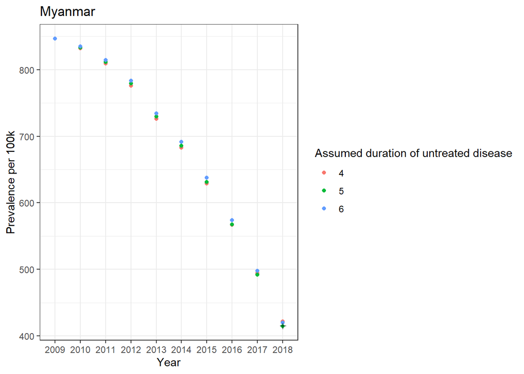

Finally we can assess what assumed duration of untreated disease allows us to get closest to the second prevalence survey estimate.

| Country | Year | 2nd Survey Prevalence | Prev difference, d=4 | Prev difference, d=5 | Prev difference, d=6 | Duration, d=4 | Duration, d=5 | Duration, d=6 | Prevalence, d=4 | Prevalence, d=5 | Prevalence, d=6 |
| --- | --- | --- | --- | --- | --- | --- | --- | --- | --- | --- | --- |
| Cambodia | 2011 | 817 | 2.813676 | 4.2552464 | 1.474412 | 2.89 | 3.28 | 3.61 | 819.8137 | 821.2552 | 815.5256 |
| China | 2010 | 108 | 2.091112 | 2.6708826 | 1.862614 | 2.20 | 2.40 | 2.55 | 110.0911 | 105.3291 | 106.1374 |
| Indonesia | 2014 | 660 | 7.556184 | 0.3008793 | 5.315951 | 2.17 | 2.37 | 2.53 | 652.4438 | 659.6991 | 654.6840 |
| Myanmar | 2018 | 415 | 6.478308 | 0.1365513 | 4.997424 | 2.29 | 2.49 | 2.64 | 421.4783 | 414.8634 | 419.9974 |
| Philippines | 2016 | 982 | 3.386688 | 0.4610365 | 3.659288 | 2.64 | 2.97 | 3.24 | 978.6133 | 982.4610 | 985.6593 |
| Vietnam | 2017 | 279 | 5.864789 | 2.8318008 | 1.171370 | 2.39 | 2.63 | 2.81 | 284.8648 | 276.1682 | 280.1714 |